# Running an MCMC

NIMBLE training materials module

NIMBLE Development Team

# A very basic MCMC

The steps of running an MCMC are as follows:

1. configure the MCMC
2. build the MCMC
3. create a compiled version of the MCMC
4. run the MCMC
5. assess and use the MCMC samples

Note that we can combine steps 1 and 2, but if we want to modify the default MCMC configuration of samplers then we need to separate the steps.

# Build the model

We first need to build the model.

```r
pumpCode <- nimbleCode({
  for (i in 1:N){

      # likelihood (data model)
      x[i] ~ dpois(lambda[i])

      # latent process (random effects)
      # linear predictor
      lambda[i] <- theta[i]*t[i]
      # random effects distribution
      theta[i] ~ dgamma(alpha,beta)
  }
  # priors on hyperparameters
  alpha ~ dexp(1.0)
  beta ~ dgamma(0.1,1.0)
})
```

```r
N <- 10
t <- c(94.3, 15.7, 62.9, 126, 5.24, 31.4, 1.05, 1.05, 2.1, 10.5)
x <- c(5, 1, 5, 14, 3, 19, 1, 1, 4, 22)
pumpConsts <- list(t = t, N = 10)
pumpData <- list(x = x)
pumpInits <- list(alpha = 1, beta = 1,
         theta = rep(0.1, pumpConsts$N))
pump <- nimbleModel(pumpCode,
          data = pumpData, constants = pumpConsts, inits = pumpInits)
```

```
## defining model...
```

```
## building model...
```

```
## setting data and initial values...
```

```
## checking model...   (use nimbleModel(..., check = FALSE) to skip model check)
```

```
## model building finished
```

```r
Cpump <- compileNimble(pump)
```

# Configuring a basic MCMC

Setting up and running an MCMC in NIMBLE takes a few more steps than in BUGS or JAGS, but with the benefit of giving the user much more control of how the MCMC operates.

First we *configure* the MCMC, which means setting up the samplers to be used for each node or group of nodes. NIMBLE provides a default configuration, but we’ll see shortly how you can modify that.

```r
pumpConf <- configureMCMC(pump, print = TRUE)
```

```
## [1]  RW sampler: alpha
## [2]  conjugate_dgamma_dgamma sampler: beta,  dep_dgamma: theta[1], theta[2], theta[3], theta[4], theta[5], theta[6], theta[7], theta[8], theta[9], theta[10]
## [3]  conjugate_dgamma_dpois sampler: theta[1],  dep_dpois: x[1]
## [4]  conjugate_dgamma_dpois sampler: theta[2],  dep_dpois: x[2]
## [5]  conjugate_dgamma_dpois sampler: theta[3],  dep_dpois: x[3]
## [6]  conjugate_dgamma_dpois sampler: theta[4],  dep_dpois: x[4]
## [7]  conjugate_dgamma_dpois sampler: theta[5],  dep_dpois: x[5]
## [8]  conjugate_dgamma_dpois sampler: theta[6],  dep_dpois: x[6]
## [9]  conjugate_dgamma_dpois sampler: theta[7],  dep_dpois: x[7]
## [10] conjugate_dgamma_dpois sampler: theta[8],  dep_dpois: x[8]
## [11] conjugate_dgamma_dpois sampler: theta[9],  dep_dpois: x[9]
## [12] conjugate_dgamma_dpois sampler: theta[10],  dep_dpois: x[10]
```

You also specify what nodes you’d like to get the MCMC samples provided as output.

```r
pumpConf$addMonitors(c('alpha', 'beta', 'theta'))
```

```
## thin = 1: alpha, beta, theta
```

# Building the MCMC algorithm for the model

Next we’ll build the MCMC algorithm for the model under the default configuration. And we’ll create a compiled (i.e., C++) version of the MCMC that is equivalent in functionality but will run much faster.

```r
pumpMCMC <- buildMCMC(pumpConf)
CpumpMCMC <- compileNimble(pumpMCMC, project = pump)
```

# Building the default MCMC algorithm (shortcut)

Instead of running both `configureMCMC` and `buildMCMC`, if you are happy to just run our default MCMC configuration, you can simply do this:

```r
pumpMCMC <- buildMCMC(pump)  # note use of model not configuration as argument
CpumpMCMC <- compileNimble(pumpMCMC, project = pump)
```

# Running the MCMC

Now let’s run the MCMC. We don’t recommend running the R version of the MCMC for very many iterations - it’s really slow - in part because iterating in R is slow and in part because iterating with a model in NIMBLE requires even more overhead.

```r
niter <- 1000
set.seed(0)
print(system.time(pumpMCMC$run(5)))  # R version
```

```
##    user  system elapsed
##   0.419   0.011   0.430
```

```r
set.seed(0)
print(system.time(
CpumpMCMC$run(niter)
))
```

```
##    user  system elapsed
##   0.026   0.001   0.026
```

# Working with MCMC output

The R and C MCMC samples are the same, so you can use the R MCMC for debugging. It’s possible to step through the code line by line using R’s debugging capabilities (not shown).

```r
Rsamples <- as.matrix(pumpMCMC$mvSamples)
samples <- as.matrix(CpumpMCMC$mvSamples)

identical(Rsamples, samples[1:5, ])
```

```
## [1] TRUE
```

Now let’s look at the MCMC performance

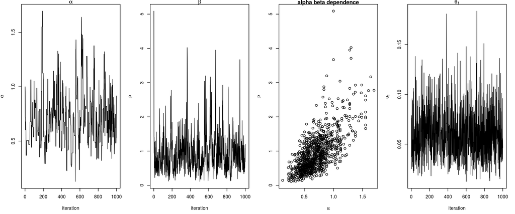

```r
par(mfrow = c(1, 4), mai = c(.6, .5, .1, .2))
ts.plot(samples[ , 'alpha'], xlab = 'iteration',
     ylab = expression(alpha), main = expression(alpha))
ts.plot(samples[ , 'beta'], xlab = 'iteration',
     ylab = expression(beta), main = expression(beta))
plot(samples[ , 'alpha'], samples[ , 'beta'], xlab = expression(alpha),
     ylab = expression(beta), main = paste(expression(alpha), expression(beta), "dependence"))
ts.plot(samples[ , 'theta[1]'], xlab = 'iteration',
     ylab = expression(theta[1]), main = expression(theta[1]))
```

# Using CODA

NIMBLE does not provide any MCMC diagnostics. (At least not yet; there’s no reason one couldn’t write code for various diagnostics using the NIMBLE system.) But one can easily use CODA or other R packages with the MCMC output from a NIMBLE MCMC.

```r
library(coda)
burnin <- 100
mcmc <- as.mcmc(samples[(burnin+1):nrow(samples), ])
crosscorr(mcmc[ , c('alpha', 'beta', 'theta[1]', 'theta[2]', 'theta[3]')])
```

```
##              alpha       beta   theta[1]   theta[2]   theta[3]
## alpha    1.0000000 0.69092205 0.14509989 0.13292548 0.10016094
## beta     0.6909221 1.00000000 0.03973338 0.04443865 0.01187130
## theta[1] 0.1450999 0.03973338 1.00000000 0.02463698 0.06586693
## theta[2] 0.1329255 0.04443865 0.02463698 1.00000000 0.02326869
## theta[3] 0.1001609 0.01187130 0.06586693 0.02326869 1.00000000
```

```r
effectiveSize(mcmc)
```

```
##     alpha      beta  theta[1]  theta[2]  theta[3]  theta[4]  theta[5]
##  82.12125 133.04247 900.00000 900.00000 900.00000 900.00000 900.00000
##  theta[6]  theta[7]  theta[8]  theta[9] theta[10]
## 900.00000 900.00000 900.00000 816.60472 900.00000
```

One could apply the commonly used Gelman-Rubin potential scale reduction factor diagnostic, but one would need to run multiple chains.

# Running multiple chains

At the moment, we haven’t set up NIMBLE to automatically run multiple chains, such as would be needed for calculation of the Gelman-Rubin potential scale reduction factor (*gelman.diag()* in the *coda* package). But it’s straightforward to do this yourself.

```r
nChains <- 3
pumpInits <- list(list(alpha = 1, beta = 1), list(alpha = 0.1, beta =30), list(alpha = 30, beta = 0.1))
out <- list()
set.seed(0)
niter <- 3000
burnIn <- 1000
for(ch in seq_len(nChains)) {
       Cpump$setInits(pumpInits[[ch]])
       Cpump$simulate(pump$getDependencies(c('alpha','beta')))
       Cmcmc <- compileNimble(pumpMCMC, project = pump, resetFunctions = TRUE)
       Cmcmc$run(niter)
       out[[ch]] <- as.mcmc(as.matrix(Cmcmc$mvSamples)[(1+burnIn):niter, ])
}
```

Considerations: you’ll want to think about how to set up the over-dispersed starting points and the number of iterations to use for burn-in.

# Assessing MCMC performance from multiple chains

```r
smp <- do.call(mcmc.list, out)
gelman.diag(smp)
```

```
## Potential scale reduction factors:
##
##           Point est. Upper C.I.
## alpha           1.01       1.03
## beta            1.01       1.02
## theta[1]        1.00       1.00
## theta[2]        1.00       1.00
## theta[3]        1.00       1.00
## theta[4]        1.00       1.00
## theta[5]        1.00       1.00
## theta[6]        1.00       1.00
## theta[7]        1.00       1.01
## theta[8]        1.00       1.00
## theta[9]        1.00       1.00
## theta[10]       1.00       1.00
##
## Multivariate psrf
##
## 1.01
```

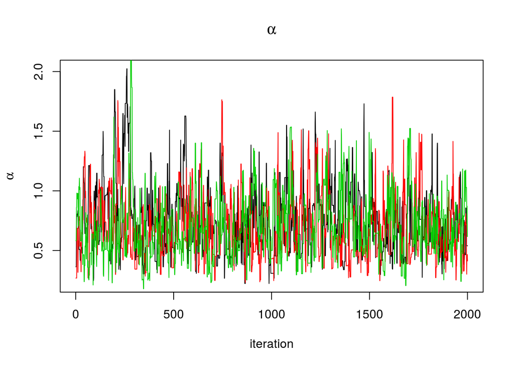

```r
# and here's a graphical representation of the information
ts.plot(out[[1]][ , 'alpha'], xlab = 'iteration',
     ylab = expression(alpha), main = expression(alpha))
sq <- seq_along(out[[1]][ , 'alpha'])
for(i in 2:3)
      lines(sq, out[[i]][ , 'alpha'], col = i)
```